# R_project

2025-01-31

# Super Bowl Ad Engagement Analysis

## Introduction

Super Bowl advertisements are a crucial aspect of the annual sports event, attracting millions of viewers and significant brand investment. This project analyzes Super Bowl ad engagement metrics to determine what factors contribute to higher audience interactions, particularly through YouTube likes and comments. The study also explores brand performance, humor’s impact on engagement, and the relationship between TV viewership and online interactions.

## Dataset Overview

The dataset consists of Super Bowl advertisements from 2000 onwards, enriched with additional metrics such as:

- Engagement Metrics: Likes, dislikes, comments, and views on YouTube
- Attributes: Whether the ad features humor, celebrities, animals, patriotic themes, danger, or explicit product placement
- TV Metrics: TV views in millions, NFL revenue from advertisements
- Ad Descriptions: Brand, year, ad url

The data was sourced from Tidy Tuesday data on GitHub and enriched using statista.

```r
library(data.table)
library(skimr)
library(readr)
library(tidyr)
library(ggplot2)
library(scales)
library(RColorBrewer)

#superbowl data from tody tuesday
sb <- fread('https://raw.githubusercontent.com/rfordatascience/tidytuesday/main/data/2021/2021-03-02/youtube.csv')
sb <- as.data.table(sb)
skim(sb)
```

Data summary

| Name | sb |
| --- | --- |
| Number of rows | 247 |
| Number of columns | 25 |
| Key | NULL |
| _______________________ |  |
| Column type frequency: |  |
| character | 10 |
| logical | 7 |
| numeric | 7 |
| POSIXct | 1 |
| ________________________ |  |
| Group variables | None |

**Variable type: character**

| skim_variable | n_missing | complete_rate | min | max | empty | n_unique | whitespace |
| --- | --- | --- | --- | --- | --- | --- | --- |
| brand | 0 | 1.00 | 3 | 9 | 0 | 10 | 0 |
| superbowl_ads_dot_com_url | 0 | 1.00 | 34 | 120 | 0 | 244 | 0 |
| youtube_url | 11 | 0.96 | 43 | 43 | 0 | 233 | 0 |
| id | 11 | 0.96 | 11 | 11 | 0 | 233 | 0 |
| kind | 16 | 0.94 | 13 | 13 | 0 | 1 | 0 |
| etag | 16 | 0.94 | 27 | 27 | 0 | 228 | 0 |
| title | 16 | 0.94 | 6 | 100 | 0 | 228 | 0 |
| description | 16 | 0.94 | 0 | 3611 | 34 | 195 | 0 |
| thumbnail | 129 | 0.48 | 48 | 48 | 0 | 118 | 0 |
| channel_title | 16 | 0.94 | 3 | 37 | 0 | 185 | 0 |

**Variable type: logical**

| skim_variable | n_missing | complete_rate | mean | count |
| --- | --- | --- | --- | --- |
| funny | 0 | 1 | 0.69 | TRU: 171, FAL: 76 |
| show_product_quickly | 0 | 1 | 0.68 | TRU: 169, FAL: 78 |
| patriotic | 0 | 1 | 0.17 | FAL: 206, TRU: 41 |
| celebrity | 0 | 1 | 0.29 | FAL: 176, TRU: 71 |
| danger | 0 | 1 | 0.30 | FAL: 172, TRU: 75 |
| animals | 0 | 1 | 0.37 | FAL: 155, TRU: 92 |
| use_sex | 0 | 1 | 0.27 | FAL: 181, TRU: 66 |

**Variable type: numeric**

| skim_variable | n_missing | complete_rate | mean | sd | p0 | p25 | p50 | p75 | p100 | hist |
| --- | --- | --- | --- | --- | --- | --- | --- | --- | --- | --- |
| year | 0 | 1.00 | 2010.19 | 5.86 | 2000 | 2005 | 2010 | 2015.00 | 2020 | ▇▇▇▇▆ |
| view_count | 16 | 0.94 | 1407556.46 | 11971111.01 | 10 | 6431 | 41379 | 170015.50 | 176373378 | ▇▁▁▁▁ |
| like_count | 22 | 0.91 | 4146.03 | 23920.40 | 0 | 19 | 130 | 527.00 | 275362 | ▇▁▁▁▁ |
| dislike_count | 22 | 0.91 | 833.54 | 6948.52 | 0 | 1 | 7 | 24.00 | 92990 | ▇▁▁▁▁ |
| favorite_count | 16 | 0.94 | 0.00 | 0.00 | 0 | 0 | 0 | 0.00 | 0 | ▁▁▇▁▁ |
| comment_count | 25 | 0.90 | 188.64 | 986.46 | 0 | 1 | 10 | 50.75 | 9190 | ▇▁▁▁▁ |
| category_id | 16 | 0.94 | 19.32 | 8.00 | 1 | 17 | 23 | 24.00 | 29 | ▃▁▂▆▇ |

**Variable type: POSIXct**

| skim_variable | n_missing | complete_rate | min | max | median | n_unique |
| --- | --- | --- | --- | --- | --- | --- |
| published_at | 16 | 0.94 | 2006-02-06 10:02:36 | 2021-01-27 13:11:29 | 2013-01-31 09:13:55 | 227 |

```r
#enriching the data by scraping data from Statista
superbowl_scraped <- fread("https://raw.githubusercontent.com/ghadena/C3-R/refs/heads/main/superbowl_scraped.csv")
superbowl_scraped <- as.data.table(superbowl_scraped)
superbowl_scraped <- superbowl_scraped[year >= 2000, ] #filtering for years after 2000
skim(superbowl_scraped)
```

Data summary

| Name | superbowl_scraped |
| --- | --- |
| Number of rows | 25 |
| Number of columns | 4 |
| Key | NULL |
| _______________________ |  |
| Column type frequency: |  |
| numeric | 4 |
| ________________________ |  |
| Group variables | None |

**Variable type: numeric**

| skim_variable | n_missing | complete_rate | mean | sd | p0 | p25 | p50 | p75 | p100 | hist |
| --- | --- | --- | --- | --- | --- | --- | --- | --- | --- | --- |
| year | 0 | 1.00 | 2012.00 | 7.36 | 2000.00 | 2006.00 | 2012.00 | 2018.00 | 2024.0 | ▇▇▇▇▇ |
| tv_views(millions) | 0 | 1.00 | 100.92 | 11.09 | 84.34 | 90.75 | 99.18 | 111.32 | 123.4 | ▇▅▃▇▁ |
| avg_cost of 30sec ad (millions $) | 2 | 0.92 | 4.03 | 1.59 | 2.10 | 2.60 | 3.80 | 5.25 | 7.0 | ▇▃▂▃▂ |
| add revenue (millions $) | 2 | 0.92 | 308.02 | 158.39 | 125.00 | 174.25 | 272.00 | 403.00 | 600.0 | ▇▂▃▂▃ |

## Research Questions

1. What attributes in Super Bowl ads contribute to higher engagement?

Examining the impact of humor, celebrity appearances, patriotism, and other attributes on likes and comments.

2. Why do funny ads get fewer likes and comments?

Investigating whether humor interacts with other factors to influence engagement.

3. Which brands consistently get the highest engagement, and why?

Analyzing top advertisers based on engagement and identifying key patterns.

4. How does TV viewership impact online engagement?

Assessing whether years with higher TV views correspond to higher YouTube likes.

## Data Processing and Cleaning

Filtered dataset to include only years 2000 onwards.

Merged additional data sources containing TV views and NFL ad revenue.

Normalized brand engagement metrics to compare advertisers fairly.

Handled missing values by omitting NA values from calculations.

Converted categorical attributes to a long format for better visualization.

```r
# Merging
dt <- merge(sb, superbowl_scraped, by = "year")

# Counting commercials by brand
sb[ , .N, by = .(brand)][order(-N)]
```

```
##         brand     N
##        <char> <int>
##  1: Bud Light    63
##  2: Budweiser    43
##  3:     Pepsi    25
##  4:   Doritos    25
##  5:   Hynudai    22
##  6: Coca-Cola    21
##  7:       Kia    13
##  8:   E-Trade    13
##  9:    Toyota    11
## 10:       NFL    11
```

```r
# Convert logical variables to long format
logical_vars <- sb %>%
  pivot_longer(cols = where(is.logical), names_to = "Variable", values_to = "Value")
```

## Attribute Analysis: What Makes Ads More Engaging?

We examined seven key attributes across Super Bowl commercials: Humor, Celebrities, Animals, Patriotism, Danger, Sex Appeal and Product Placement

To answer the first research question, I aggregated the dataset, calculating the average likes and average comments for ads with and without each attribute. Then counted how many times each attribute appeared in the dataset to understand their prevalence. and finally created visualizations to compare engagement across different categories.

```r
# Define the list of categorical columns
categories <- c("funny", "patriotic", "celebrity", "danger", "animals", "use_sex", "show_product_quickly")

# Initialize an empty data.table to store aggregated results
cat_agg <- data.table(category = character(), value = logical(), avg_likes = numeric(), avg_comments = numeric())

# Loop through each category and compute avg_likes and avg_comments
for (category in categories) {
  temp_dt <- dt[, .(avg_likes = mean(like_count, na.rm = TRUE),
                    avg_comments = mean(comment_count, na.rm = TRUE)),
                by = category]
  setnames(temp_dt, category, "value") # Rename the grouping column to a generic name "value"
  temp_dt[, category := category]  # Add a new column to indicate the category name
  cat_agg <- rbind(cat_agg, temp_dt, fill = TRUE)   # Bind the results to the main results_dt
}
setcolorder(cat_agg, c("category", "value", "avg_likes", "avg_comments")) # Reorder columns for clarity
print(cat_agg)
```

```
##                 category  value avg_likes avg_comments
##                   <char> <lgcl>     <num>        <num>
##  1:                funny   TRUE 3587.0000    120.07190
##  2:                funny  FALSE 5409.9275    340.68116
##  3:            patriotic  FALSE 3515.9895    108.72826
##  4:            patriotic   TRUE 7566.2571    575.57895
##  5:            celebrity  FALSE 3876.1006    167.68387
##  6:            celebrity   TRUE 4796.3182    237.11940
##  7:               danger  FALSE 3917.6968    144.31373
##  8:               danger   TRUE 4651.6286    286.92754
##  9:              animals   TRUE 3060.5060    148.04819
## 10:              animals  FALSE 4780.5282    212.87770
## 11:              use_sex  FALSE 5462.2590    242.68712
## 12:              use_sex   TRUE  442.7458     39.32203
## 13: show_product_quickly   TRUE 4245.7516    132.21290
## 14: show_product_quickly  FALSE 3915.7941    319.17910
```

Visualizations

To illustrate these insights, I included three grouped bar charts: 1. Count of occurrences of each attribute in the dataset. 2. Average likes received by ads based on whether they had the attribute or not. 3. Average comments received by ads based on whether they had the attribute or not.

These visualizations help us identify patterns in Super Bowl ad engagement and provide insights into which elements contribute to higher audience interaction.

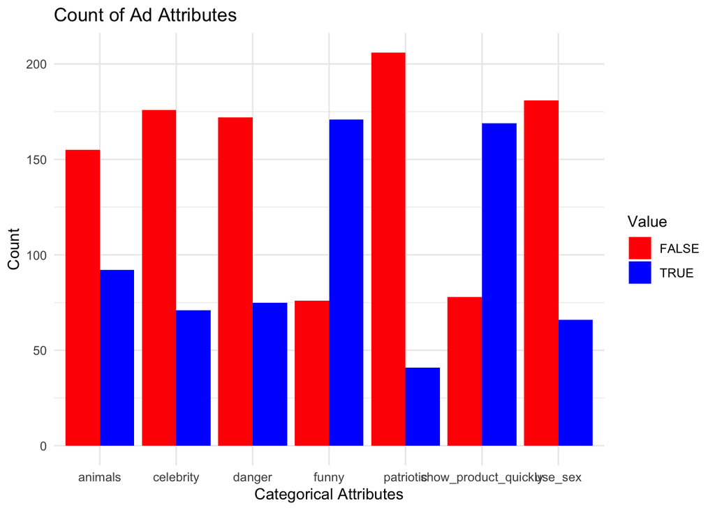

```r
#chart 1 counting the occurrence of categories
ggplot(logical_vars, aes(x = Variable, fill = Value)) +
  geom_bar(position = "dodge") +
  ggtitle("Count of Ad Attributes") +
  xlab("Categorical Attributes") +
  ylab("Count") +
  theme_minimal() +
  scale_fill_manual(values = c("TRUE" = "blue", "FALSE" = "red"))
```

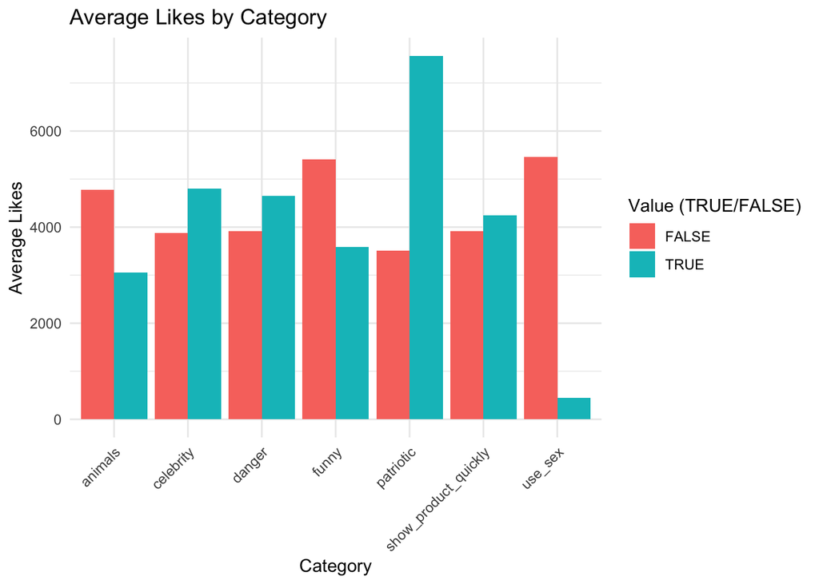

```r
#chart 2 average likes by category
ggplot(cat_agg, aes(x = category, y = avg_likes, fill = value)) +
  geom_bar(stat = "identity", position = "dodge") +
  labs(title = "Average Likes by Category", x = "Category", y = "Average Likes", fill = "Value (TRUE/FALSE)") +
  theme_minimal() +
  theme(axis.text.x = element_text(angle = 45, hjust = 1))
```

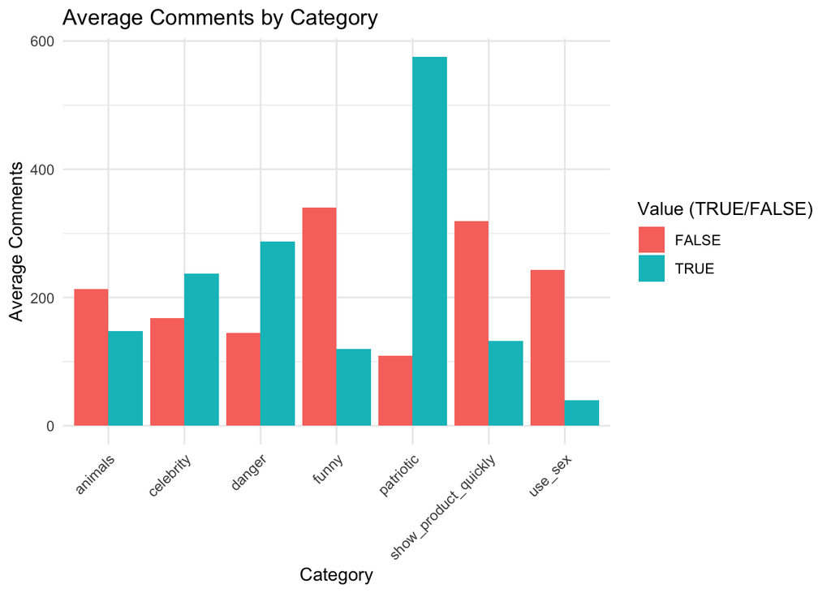

```r
#chart 3 average commnets by category
ggplot(cat_agg, aes(x = category, y = avg_comments, fill = value)) +
  geom_bar(stat = "identity", position = "dodge") +
  labs(title = "Average Comments by Category", x = "Category", y = "Average Comments", fill = "Value (TRUE/FALSE)") +
  theme_minimal() +
  theme(axis.text.x = element_text(angle = 45, hjust = 1))
```

## Does Humor Really Boost Engagement? Investigating Funny Super Bowl Ads

My initial analysis showed that funny ads received fewer likes and comments than non-funny ones, despite making up the majority of the dataset. To understand why, I explored several factors.

**Do Funny Ads Actually Get Less Engagement?**

Since humor was expected to drive engagement, I first checked whether funny ads simply had fewer observations, but they actually outnumbered non-funny ads nearly 2:1. This ruled out sample size as a factor. Next, I examined whether funny ads had more variation in likes, but the standard deviation was lower than for non-funny ads. This means funny ads were more consistent in performance. I also analyzed the trend of average likes over time for funny vs. non-funny ads, but the results were inconclusive, showing a largely random pattern—possibly due to a few viral ads and small sample size heavily distorting the data.

**Do Other Factors Influence Funny Ads’ Performance?**

Certain ad attributes, like celebrity appearances, typically boost engagement. However, I found that celebrity ads that weren’t funny performed best (~10,000 likes on average), while funny ads without celebrities got ~4,700 likes. Funny ads with celebrities performed even worse. This suggests that while celebrities usually increase engagement, humor weakens their impact, possibly by shifting focus away from them.

**Are Funny Ads More Entertaining But Less Engaging?**

Although funny ads received fewer likes per view, they were watched more often than non-funny ads. This suggests they are entertaining enough to keep viewers watching, but not compelling enough to drive interaction. A check on dislikes revealed that funny ads also received fewer dislikes, reinforcing the idea that they are well-received but not particularly engaging.

**Are Funny Ads Misclassified?**

The dataset defines a funny ad as jokey, goofy, weird, or silly, or one that attempts to be humorous. However, after reviewing top-performing ads, I found that some—like Super Bowl Babies Choir and Budweiser’s Donkey ad—weren’t labeled as funny, even though they fit the definition. This suggests potential misclassification, which may affect results.

Humor is highly subjective—what one person finds funny, another may not. Unlike other attributes like celebrity appearances, animals, or product placement, which are more objective, humor varies by perception. This subjectivity could explain why the data contradicts expectations, showing that funny ads receive fewer likes and comments despite their entertainment value.

```r
#lets check the distribution of funny videos (count and standard deviation)
dt[, .N, by = funny]
```

```
##     funny     N
##    <lgcl> <int>
## 1:   TRUE   171
## 2:  FALSE    76
```

```r
dt[, .(avg_likes = mean(like_count, na.rm = TRUE),
       sd_likes = sd(like_count, na.rm = TRUE)),
   by = funny]
```

```
##     funny avg_likes sd_likes
##    <lgcl>     <num>    <num>
## 1:   TRUE  3587.000 23809.09
## 2:  FALSE  5409.928 24297.59
```

```r
#examining the trend overtime
dt[, .(avg_likes = mean(like_count, na.rm = TRUE)), by = .(year, funny)][order(year, -avg_likes)]
```

```
##      year  funny   avg_likes
##     <int> <lgcl>       <num>
##  1:  2000   TRUE  4198.66667
##  2:  2001  FALSE   250.50000
##  3:  2001   TRUE    59.60000
##  4:  2002  FALSE  3285.50000
##  5:  2002   TRUE   105.28571
##  6:  2003   TRUE    76.00000
##  7:  2003  FALSE    42.00000
##  8:  2004  FALSE  3744.00000
##  9:  2004   TRUE   261.40000
## 10:  2005   TRUE    23.33333
## 11:  2006   TRUE   428.00000
## 12:  2007   TRUE   563.33333
## 13:  2007  FALSE   149.80000
```

[output cut: 27 more lines]

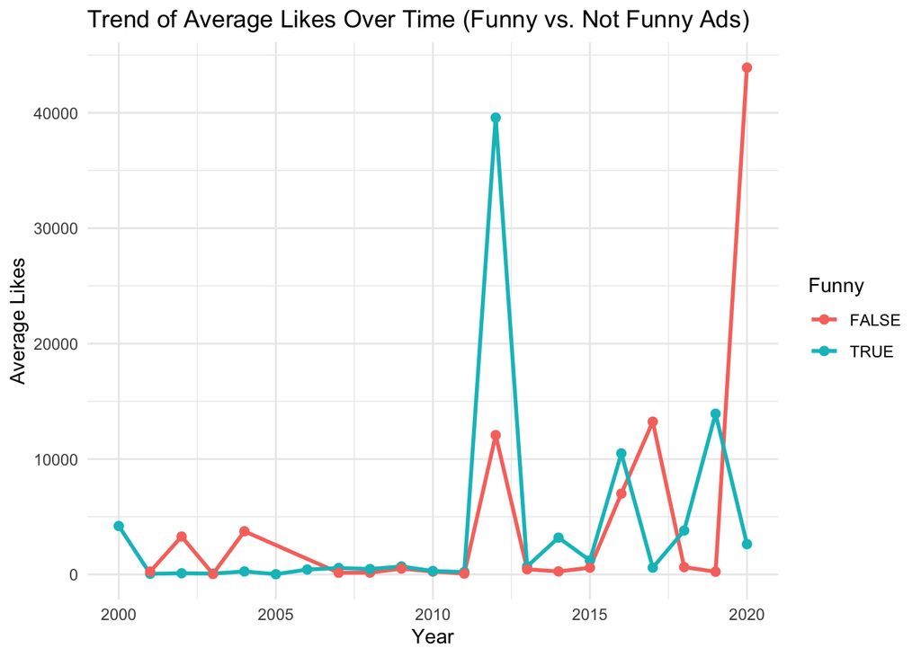

```r
ggplot(dt[, .(avg_likes = mean(like_count, na.rm = TRUE)), by = .(year, funny)],
       aes(x = year, y = avg_likes, color = funny, group = funny)) +
  geom_line(size = 1) +
  geom_point(size = 2) +
  labs(title = "Trend of Average Likes Over Time (Funny vs. Not Funny Ads)",
       x = "Year", y = "Average Likes", color = "Funny") +
  theme_minimal()
```

```r
#examining the influence of other factors
dt[, .(avg_likes = mean(like_count, na.rm = TRUE)), by = .(funny, celebrity, animals)][order(-avg_likes)]
```

```
##     funny celebrity animals  avg_likes
##    <lgcl>    <lgcl>  <lgcl>      <num>
## 1:  FALSE      TRUE   FALSE 10140.9524
## 2:   TRUE     FALSE   FALSE  4749.9118
## 3:  FALSE     FALSE    TRUE  4613.0000
## 4:   TRUE      TRUE   FALSE  3071.0345
## 5:   TRUE     FALSE    TRUE  3031.5000
## 6:  FALSE     FALSE   FALSE  2242.5417
## 7:   TRUE      TRUE    TRUE   942.1333
## 8:  FALSE      TRUE    TRUE   405.0000
```

```r
#funny videos get more views but less likes
dt[, .(avg_views = mean(view_count, na.rm = TRUE), avg_likes = mean(like_count, na.rm = TRUE)), by = funny]
```

```
##     funny avg_views avg_likes
##    <lgcl>     <num>     <num>
## 1:   TRUE   1462225  3587.000
## 2:  FALSE   1286830  5409.928
```

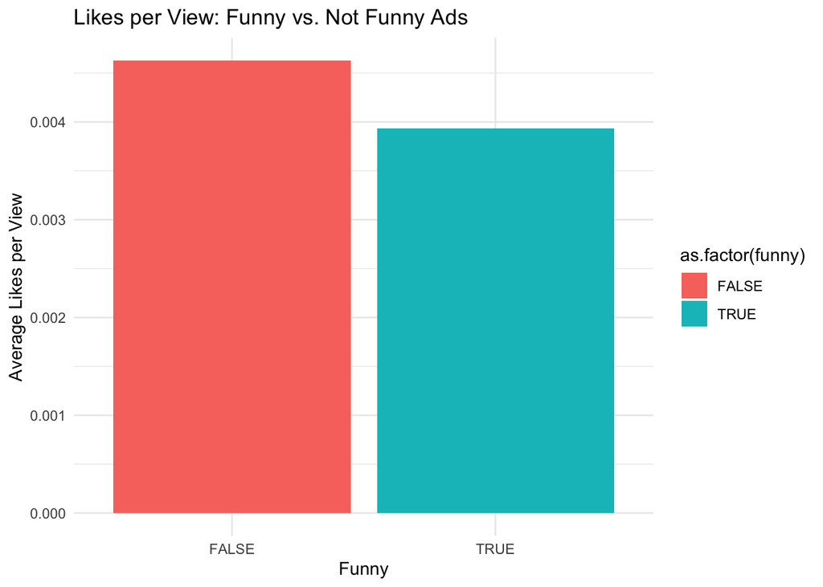

```r
dt[, likes_per_view := like_count / view_count]
ggplot(dt[, .(avg_likes_per_view = mean(likes_per_view, na.rm = TRUE)), by = funny],
       aes(x = as.factor(funny), y = avg_likes_per_view, fill = as.factor(funny))) +
  geom_bar(stat = "identity") +
  labs(title = "Likes per View: Funny vs. Not Funny Ads",
       x = "Funny", y = "Average Likes per View") +
  theme_minimal()
```

```r
#lets check the another engagement metric, number of dislikes.
dt[, .(avg_dislikes = mean(dislike_count, na.rm = TRUE)), by = funny]
```

```
##     funny avg_dislikes
##    <lgcl>        <num>
## 1:   TRUE     746.5513
## 2:  FALSE    1030.2029
```

```r
#lets check the top 20 videos by engagement and examine potential classification issues. (superbowl babay choir and the budwiser donley videos are misclassified imo)
dt[order(-like_count)][1:20, .(year, funny, brand, title, like_count, view_count)]
```

```
##      year  funny     brand
##     <int> <lgcl>    <char>
##  1:  2012   TRUE   Doritos
##  2:  2020  FALSE       NFL
##  3:  2019   TRUE Bud Light
##  4:  2012  FALSE Coca-Cola
##  5:  2016   TRUE Coca-Cola
##  6:  2017  FALSE Budweiser
##  7:  2000   TRUE Budweiser
##  8:  2016  FALSE       NFL
##  9:  2018   TRUE       NFL
## 10:  2014   TRUE   Doritos
## 11:  2020   TRUE   Doritos
## 12:  2002  FALSE     Pepsi
## 13:  2004  FALSE Budweiser
```

[output cut: 54 more lines]

**Visualizing Likes Distribution for Funny vs. Non-Funny Ads**

To compare engagement, I created three boxplots: • The first included all ads, showing non-funny ads had higher likes overall. • The second excluded the top 5% of extreme values, revealing clearer patterns. • The third used a log scale, further confirming that non-funny ads consistently received more likes than funny ones.

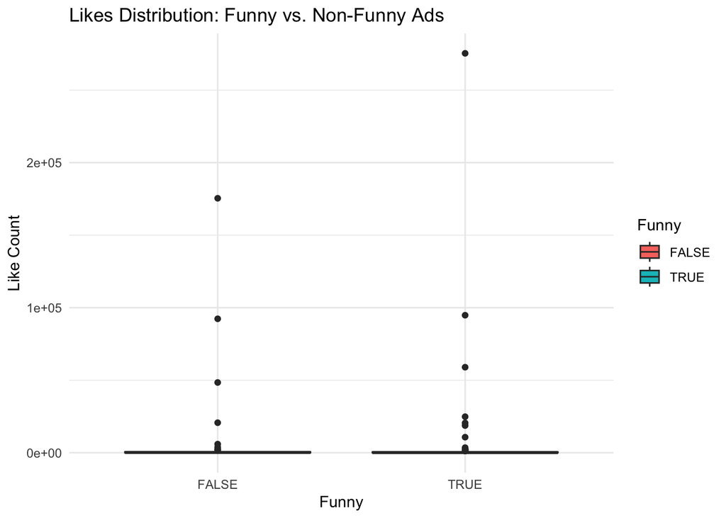

```r
# including all observations
ggplot(dt, aes(x = as.factor(funny), y = like_count, fill = as.factor(funny))) +
  geom_boxplot() +
  labs(title = "Likes Distribution: Funny vs. Non-Funny Ads",
       x = "Funny", y = "Like Count", fill = "Funny") +
  theme_minimal()
```

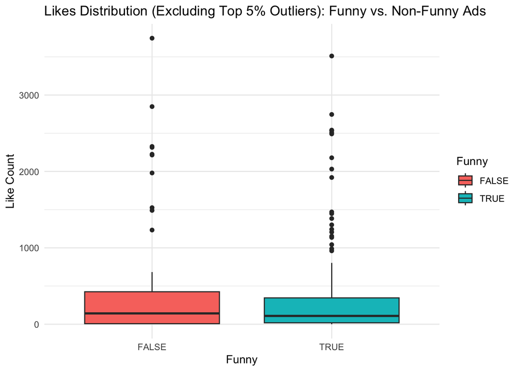

```r
# excluding outliars - top 5%
dt_filtered <- dt[like_count <= quantile(like_count, 0.95, na.rm = TRUE)]

ggplot(dt_filtered, aes(x = as.factor(funny), y = like_count, fill = as.factor(funny))) +
  geom_boxplot() +
  labs(title = "Likes Distribution (Excluding Top 5% Outliers): Funny vs. Non-Funny Ads",
       x = "Funny", y = "Like Count", fill = "Funny") +
  theme_minimal()
```

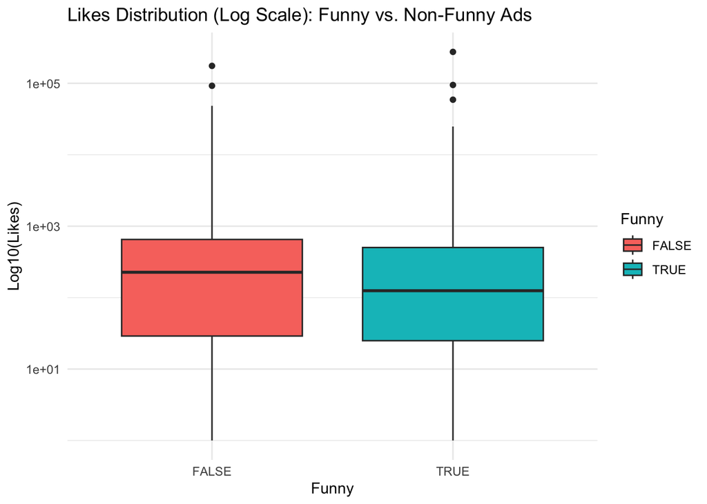

```r
# on log scale
ggplot(dt, aes(x = as.factor(funny), y = like_count, fill = as.factor(funny))) +
  geom_boxplot() +
  scale_y_log10() +
  labs(title = "Likes Distribution (Log Scale): Funny vs. Non-Funny Ads",
       x = "Funny", y = "Log10(Likes)", fill = "Funny") +
  theme_minimal()
```

**Ad Success Is More Than Just Likes**

While my analysis focuses on likes and comments as engagement metrics, they do not fully define ad success. A truly successful ad could drive sales, brand awareness, or cultural impact—factors that are difficult to quantify but often more important than online engagement. Some funny ads may generate buzz or brand recognition without necessarily earning more likes.

While humor is often seen as a winning strategy, simply being funny does not guarantee engagement. Other elements—emotional appeal, storytelling, and branding strategies—may play a bigger role in making an ad truly successful.

## Brand Performance: Which Brands Dominate Engagement?

To investigate which brands consistently received higher likes and engagement, I created two datasets: 1. Brand Performance Table – Calculated average likes, comments, dislikes, and ad counts for each brand. 2. Attribute Composition Table – Measured how often each brand used specific features (e.g., funny, celebrity, patriotic) in their ads, expressed as percentages. This table also included average likes, comments, dislikes, and views per brand.

```r
# Calculate average likes, comments, dislikes, and ad counts for each brand
brand_engagement <- dt[, .(
  avg_likes = mean(like_count, na.rm = TRUE),
  avg_comments = mean(comment_count, na.rm = TRUE),
  avg_dislikes = mean(dislike_count, na.rm = TRUE),
  total_ads = .N
), by = brand][order(-avg_likes)]

print(brand_engagement)
```

```
##         brand  avg_likes avg_comments avg_dislikes total_ads
##        <char>      <num>        <num>        <num>     <int>
##  1:       NFL 24918.1111   1389.33333   1171.22222        11
##  2:   Doritos 14180.4783    166.31818   4223.73913        25
##  3: Coca-Cola  8011.5500    132.35000   2314.85000        21
##  4: Budweiser  2399.0541    312.65789    492.83784        43
##  5: Bud Light  1863.9286    147.77586    245.19643        63
##  6:     Pepsi   616.5000     53.62500     30.25000        25
##  7:    Toyota   531.6000     59.22222     38.50000        11
##  8:   E-Trade   218.6667     31.20000     11.08333        13
##  9:   Hynudai   191.0909     15.90476     13.13636        22
## 10:       Kia   177.2500     13.63636      5.25000        13
```

```r
# Calculate attribute contribution and average engagement (likes, comments, dislikes)
attribute_contribution <- dt[, .(
  funny_pct = mean(funny, na.rm = TRUE) * 100,
  celebrity_pct = mean(celebrity, na.rm = TRUE) * 100,
  animals_pct = mean(animals, na.rm = TRUE) * 100,
  product_pct = mean(show_product_quickly, na.rm = TRUE) * 100,
  patriotic_pct = mean(patriotic, na.rm = TRUE) * 100,
  danger_pct = mean(danger, na.rm = TRUE) * 100,
  sex_pct = mean(use_sex, na.rm = TRUE) * 100,
  avg_likes = mean(like_count, na.rm = TRUE),
  avg_comments = mean(comment_count, na.rm = TRUE),
  avg_dislikes = mean(dislike_count, na.rm = TRUE),
  avg_views = mean(view_count, na.rm = TRUE)  # Removed * 100
), by = brand][order(-avg_likes)]

print(attribute_contribution)
```

```
##         brand funny_pct celebrity_pct animals_pct product_pct patriotic_pct
##        <char>     <num>         <num>       <num>       <num>         <num>
##  1:       NFL  18.18182      72.72727     0.00000    54.54545     36.363636
##  2:   Doritos  96.00000      16.00000    40.00000    88.00000      4.000000
##  3: Coca-Cola  38.09524      28.57143    57.14286    71.42857     23.809524
##  4: Budweiser  48.83721      11.62791    55.81395    62.79070     37.209302
##  5: Bud Light  95.23810      26.98413    38.09524    82.53968      4.761905
##  6:     Pepsi  72.00000      64.00000    12.00000    60.00000     12.000000
##  7:    Toyota  54.54545      18.18182    27.27273    81.81818     18.181818
##  8:   E-Trade  92.30769       0.00000    30.76923    53.84615     15.384615
##  9:   Hynudai  54.54545      27.27273    31.81818    54.54545     13.636364
## 10:       Kia  61.53846      53.84615    38.46154    30.76923     15.384615
##     danger_pct   sex_pct  avg_likes avg_comments avg_dislikes  avg_views
##          <num>     <num>      <num>        <num>        <num>      <num>
##  1:    0.00000  0.000000 24918.1111   1389.33333   1171.22222 4097797.78
##  2:   44.00000 24.000000 14180.4783    166.31818   4223.73913 8550789.43
##  3:   28.57143  4.761905  8011.5500    132.35000   2314.85000 1618888.35
##  4:   16.27907 18.604651  2399.0541    312.65789    492.83784  974118.08
##  5:   42.85714 42.857143  1863.9286    147.77586    245.19643  240237.19
##  6:   24.00000 44.000000   616.5000     53.62500     30.25000  118028.80
##  7:   36.36364  9.090909   531.6000     59.22222     38.50000  113519.00
##  8:   23.07692 23.076923   218.6667     31.20000     11.08333  144923.42
##  9:   27.27273 13.636364   191.0909     15.90476     13.13636   47743.27
## 10:   38.46154 46.153846   177.2500     13.63636      5.25000   32287.15
```

**Which Brands Receive the Most Likes?**

A simple bar chart of average likes per brand revealed that: • NFL led with ~25,000 average likes per ad. • Doritos followed with ~15,000. • Coca-Cola, Budweiser, and Bud Light came next. • The remaining brands—Pepsi, Toyota, E-Trade, Hyundai, and Kia—all averaged under 1,000 likes per ad.

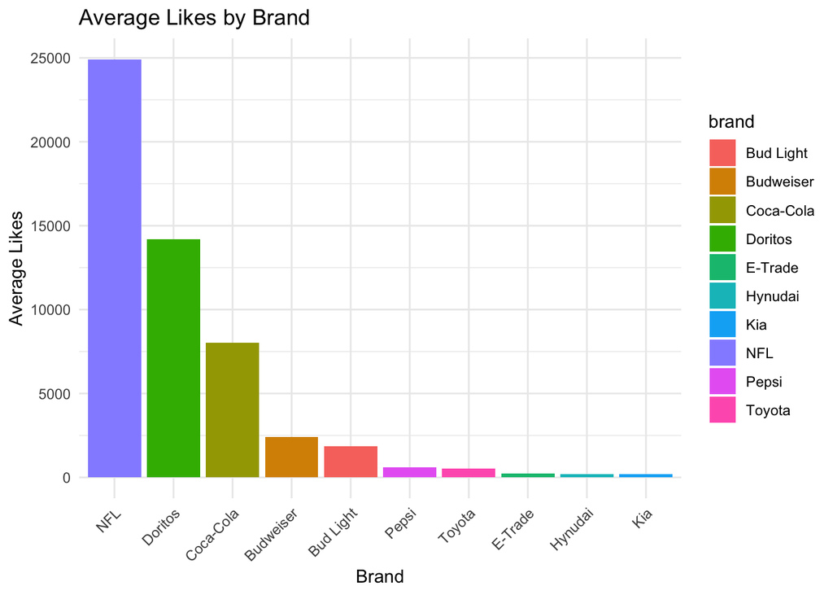

```r
#average likes per brand
ggplot(attribute_contribution, aes(x = reorder(brand, -avg_likes), y = avg_likes, fill = brand)) +
  geom_bar(stat = "identity") +
  labs(title = "Average Likes by Brand", x = "Brand", y = "Average Likes") +
  theme_minimal() +
  theme(axis.text.x = element_text(angle = 45, hjust = 1))
```

**What Makes Certain Brands More Engaging?**

To explore why some brands performed better, I normalized attribute percentages per brand to sum to 100% and converted the data into a long format for visualization.

```r
# Normalize attribute percentages to sum to 100% per brand
attribute_contribution[, total_pct := funny_pct + celebrity_pct + animals_pct + product_pct + patriotic_pct + danger_pct + sex_pct]
attribute_contribution[, ':=' (
  funny_pct = funny_pct / total_pct * 100,
  celebrity_pct = celebrity_pct / total_pct * 100,
  animals_pct = animals_pct / total_pct * 100,
  product_pct = product_pct / total_pct * 100,
  patriotic_pct = patriotic_pct / total_pct * 100,
  danger_pct = danger_pct / total_pct * 100,
  sex_pct = sex_pct / total_pct * 100
)]

# Convert data to long format for the stacked bar
attribute_long <- melt(attribute_contribution, id.vars = "brand",
                       measure.vars = c("funny_pct", "celebrity_pct", "animals_pct", "product_pct", "patriotic_pct", "danger_pct", "sex_pct"),
                       variable.name = "attribute", value.name = "percentage")
```

A stacked bar chart showed that NFL, the top performer, used celebrities the most, which may have contributed to its high engagement. NFL ads also incorporated patriotic themes more than any other brand, suggesting that emotional appeal might play a role in driving likes.

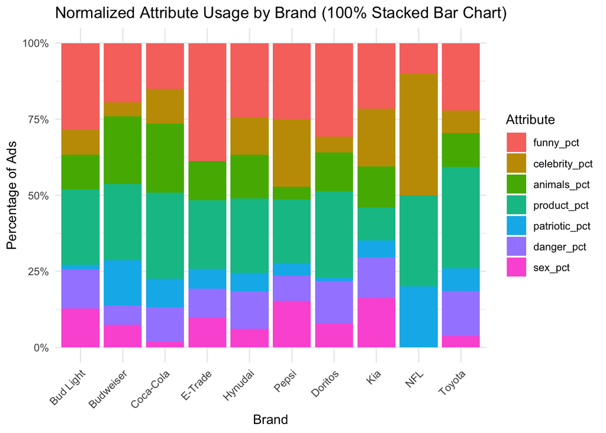

```r
# chart 6: Create a 100% stacked bar chart
ggplot(attribute_long, aes(x = reorder(brand, -percentage), y = percentage, fill = attribute)) +
  geom_bar(stat = "identity", position = "fill") +  # "fill" ensures each bar sums to 100%
  scale_y_continuous(labels = scales::percent_format(scale = 100)) +  # Format y-axis as percentages
  labs(title = "Normalized Attribute Usage by Brand (100% Stacked Bar Chart)",
       x = "Brand", y = "Percentage of Ads", fill = "Attribute") +
  theme_minimal() +
  theme(axis.text.x = element_text(angle = 45, hjust = 1))
```

**Adding an Extra Layer: Likes as a Percentage of Total Engagement**

To enhance the analysis, I calculated each brand’s share of total likes and overlaid this on the stacked bar chart. This provided a clearer picture of how brand attributes correlate with engagement levels.

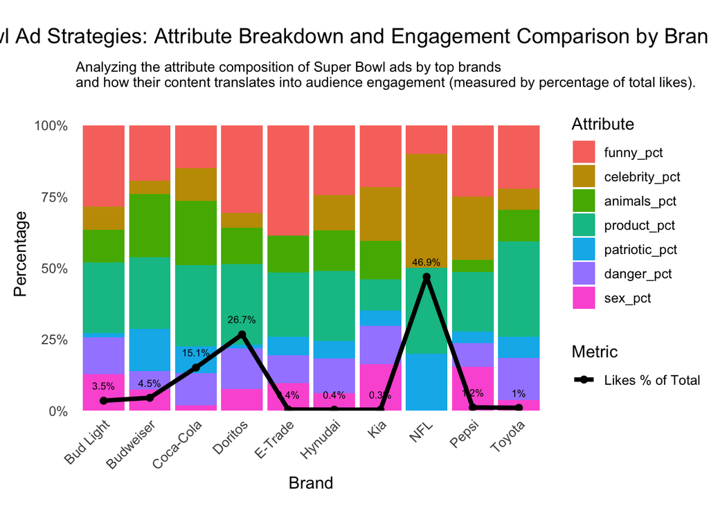

```r
# Calculate % of total likes for each brand
total_likes <- sum(attribute_contribution$avg_likes, na.rm = TRUE)
attribute_contribution[, likes_pct := (avg_likes / total_likes) * 100]

ggplot() +
  # Stacked bar chart (attributes)
  geom_bar(data = attribute_long,
           aes(x = brand, y = percentage / 100, fill = attribute),
           stat = "identity", position = "fill") +

  # Line and points for % of total likes (on the same y-axis)
  geom_line(data = attribute_contribution,
            aes(x = brand, y = likes_pct / 100, group = 1, color = "Likes % of Total"),
            size = 1.5) +
  geom_point(data = attribute_contribution,
             aes(x = brand, y = likes_pct / 100, color = "Likes % of Total"),
             size = 2) +
  scale_color_manual(values = c("Likes % of Total" = "black"), name = "Metric") +  # Add to legend

  # Labels for % of total likes
  geom_text(data = attribute_contribution,
            aes(x = brand, y = (likes_pct / 100) + 0.04, label = paste0(round(likes_pct, 1), "%")),
            vjust = -0, color = "black", size = 2.5) +

  # Formatting
  scale_y_continuous(labels = percent_format(),
                     breaks = seq(0, 1, by = 0.25),  # Set ticks at 0, 25, 50, 75, 100
                     expand = expansion(mult = c(0, 0.1))) +  # Add space for labels

  labs(title = "Super Bowl Ad Strategies: Attribute Breakdown and Engagement Comparison by Brand",
       subtitle = "Analyzing the attribute composition of Super Bowl ads by top brands \nand how their content translates into audience engagement (measured by percentage of total likes).",
       x = "Brand", y = "Percentage", fill = "Attribute") +

  # Theme adjustments
  theme_minimal(base_size = 12) +  # Keep minimal theme
  theme(panel.grid.major = element_blank(),   # Remove major grid lines
        panel.grid.minor = element_blank(),   # Remove minor grid lines
        axis.text.x = element_text(angle = 45, hjust = 1, vjust = 1),
        plot.title = element_text(hjust = 0.5, size = 15, margin = margin( b = 10)),  # Add top margin
        plot.subtitle = element_text(hjust = 0, size = 10, margin = margin(b = 5)),  # Add bottom margin
        plot.margin = margin(t = 20, r = 0, b = 10, l = 10)
        )  # Better x-axis rotation
```

## Does Higher TV Viewership Lead to More Online Engagement?

One question I explored was whether years with higher Super Bowl TV viewership also led to more engagement on YouTube. If more people saw the ads on TV, did that translate into more online reactions? This could help determine whether traditional TV exposure still influences digital engagement or if some brands are simply better at making viral ads.

**Data Challenges & Adjustments**

Initially, I plotted a scatter plot of TV views vs. YouTube likes per ad, but the visualization was misleading because: 1. TV viewership data was aggregated per year, while likes were per individual ad, making direct comparisons inaccurate. 2. A single extreme outlier—the 2012 Doritos ad (275,000 likes)—heavily skewed the trend.

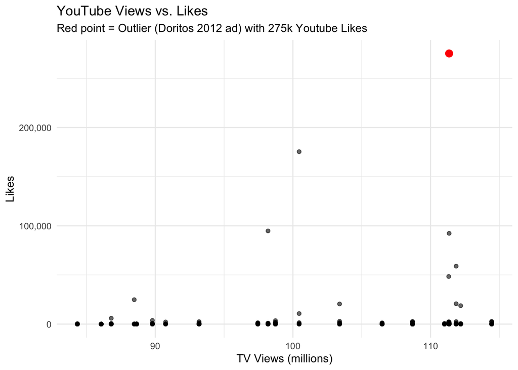

```r
#correcting column name
setnames(dt, "tv_views(millions)", "tv_views_million")

#TV viewership and youtube likes
ggplot(dt, aes(x = tv_views_million, y = like_count)) +
  geom_point(alpha = 0.6) +
  geom_point(data = dt[which.max(like_count)], aes(x = tv_views_million , y = like_count),
             color = "red", size = 3) +
  scale_x_continuous(labels = scales::comma) +  # No scientific notation
  scale_y_continuous(labels = scales::comma) +  # No scientific notation
  labs(title = "YouTube Views vs. Likes",
       x = "TV Views (millions)", y = "Likes",
       subtitle = "Red point = Outlier (Doritos 2012 ad) with 275k Youtube Likes") +
  theme_minimal()
```

```r
#identifying the outliar
dt[which.max(view_count)]
```

```
## Key: <year>
##     year   brand                          superbowl_ads_dot_com_url
##    <int>  <char>                                             <char>
## 1:  2012 Doritos https://superbowl-ads.com/2012-doritos-sling-baby/
##                                    youtube_url  funny show_product_quickly
##                                         <char> <lgcl>               <lgcl>
## 1: https://www.youtube.com/watch?v=6SWNLDdnz0A   TRUE                 TRUE
##    patriotic celebrity danger animals use_sex          id          kind
##       <lgcl>    <lgcl> <lgcl>  <lgcl>  <lgcl>      <char>        <char>
## 1:     FALSE     FALSE  FALSE   FALSE   FALSE 6SWNLDdnz0A youtube#video
##                           etag view_count like_count dislike_count
##                         <char>      <int>      <int>         <int>
## 1: BB4lUj_1vsbD0I0kNQ_DdZovEcw  176373378     275362         92990
##    favorite_count comment_count        published_at              title
##             <int>         <int>              <POSc>             <char>
## 1:              0          1234 2013-04-12 22:49:58 Doritos Sling Baby
##                                                                                                                                                                description
##                                                                                                                                                                     <char>
## 1: Top ad of the 2012 Super Bowl according to USA Today Ad Meter\nRated Most Memorable Super Bowl ad of 2012 by Nielsen\nRated Best-Liked Super Bowl ad of 2012 by Nielsen
##                                           thumbnail   channel_title category_id
##                                              <char>          <char>       <int>
## 1: https://i.ytimg.com/vi/6SWNLDdnz0A/sddefault.jpg Madison McQueen          25
##    tv_views_million avg_cost of 30sec ad (millions $) add revenue (millions $)
##               <num>                             <num>                    <num>
## 1:           111.35                               3.5                      244
##    likes_per_view
##             <num>
## 1:    0.001561245
```

```r
dt[which.max(like_count)]
```

```
## Key: <year>
##     year   brand                          superbowl_ads_dot_com_url
##    <int>  <char>                                             <char>
## 1:  2012 Doritos https://superbowl-ads.com/2012-doritos-sling-baby/
##                                    youtube_url  funny show_product_quickly
##                                         <char> <lgcl>               <lgcl>
## 1: https://www.youtube.com/watch?v=6SWNLDdnz0A   TRUE                 TRUE
##    patriotic celebrity danger animals use_sex          id          kind
##       <lgcl>    <lgcl> <lgcl>  <lgcl>  <lgcl>      <char>        <char>
## 1:     FALSE     FALSE  FALSE   FALSE   FALSE 6SWNLDdnz0A youtube#video
##                           etag view_count like_count dislike_count
##                         <char>      <int>      <int>         <int>
## 1: BB4lUj_1vsbD0I0kNQ_DdZovEcw  176373378     275362         92990
##    favorite_count comment_count        published_at              title
##             <int>         <int>              <POSc>             <char>
## 1:              0          1234 2013-04-12 22:49:58 Doritos Sling Baby
##                                                                                                                                                                description
##                                                                                                                                                                     <char>
## 1: Top ad of the 2012 Super Bowl according to USA Today Ad Meter\nRated Most Memorable Super Bowl ad of 2012 by Nielsen\nRated Best-Liked Super Bowl ad of 2012 by Nielsen
##                                           thumbnail   channel_title category_id
##                                              <char>          <char>       <int>
## 1: https://i.ytimg.com/vi/6SWNLDdnz0A/sddefault.jpg Madison McQueen          25
##    tv_views_million avg_cost of 30sec ad (millions $) add revenue (millions $)
##               <num>                             <num>                    <num>
## 1:           111.35                               3.5                      244
##    likes_per_view
##             <num>
## 1:    0.001561245
```

To correct this, I aggregated likes per year and created a new yearly engagement dataset, allowing for a clearer comparison between average YouTube likes and total TV viewership per year.

[figure not shown]

```r
# Aggregate data: Average likes per year
yearly_engagement <- dt[, .(avg_likes = mean(like_count, na.rm = TRUE)), by = .(year, tv_views_million)]

# Load necessary library for ColorBrewer palettes
display.brewer.all()  # Shows all available palettes
```

```r
# Define a color palette for years
year_colors <- brewer.pal(n = 12, name = "RdPu")  # Using a ColorBrewer palette

# Identify the outliers
max_outlier <- yearly_engagement[which.max(avg_likes)]  # 2012 (doritos ad - 275k likes)
second_outlier <- yearly_engagement[order(-avg_likes)][2]  # 2020
second_outlier
```

```
##     year tv_views_million avg_likes
##    <int>            <num>     <num>
## 1:  2020           100.45  20976.56
```

```r
dt[order(-like_count)][2]  # (nfl LIV comercial - 175k likes)
```

```
##     year  brand                    superbowl_ads_dot_com_url
##    <int> <char>                                       <char>
## 1:  2020    NFL https://superbowl-ads.com/2020-nfl-next-100/
##                                    youtube_url  funny show_product_quickly
##                                         <char> <lgcl>               <lgcl>
## 1: https://www.youtube.com/watch?v=lbkafMhmvMo  FALSE                FALSE
##    patriotic celebrity danger animals use_sex          id          kind
##       <lgcl>    <lgcl> <lgcl>  <lgcl>  <lgcl>      <char>        <char>
## 1:      TRUE      TRUE  FALSE   FALSE   FALSE lbkafMhmvMo youtube#video
##                           etag view_count like_count dislike_count
##                         <char>      <int>      <int>         <int>
## 1: GJ7PT7v2TCLH_na-2HG7nYXBEMI   26727063     175429          7445
##    favorite_count comment_count        published_at
##             <int>         <int>              <POSc>
## 1:              0          8441 2020-02-03 00:21:31
##                                         title
##                                        <char>
## 1: NEXT 100  || NFL Super Bowl LIV Commercial
##                                                                                                                                                                                                                                                                                                          …
##                                                                                                                                                                                                                                                                                                          …
## 1: A kick return 100 years in the making. Here’s to the next 100 and the game’s future stars! #NFLNext100 #SBLIV \n\nSubscribe to NFL: http://j.mp/1L0bVBu\n\nCheck out our other channels:\nNFL Vault http://www.youtube.com/nflvault\nNFL Network http://www.youtube.com/nflnetwork\nNFL Films http://w…
##                                           thumbnail channel_title category_id
##                                              <char>        <char>       <int>
## 1: https://i.ytimg.com/vi/lbkafMhmvMo/sddefault.jpg           NFL          17
##    tv_views_million avg_cost of 30sec ad (millions $) add revenue (millions $)
##               <num>                             <num>                    <num>
## 1:           100.45                               5.6                      449
##    likes_per_view
##             <num>
## 1:    0.006563722
```

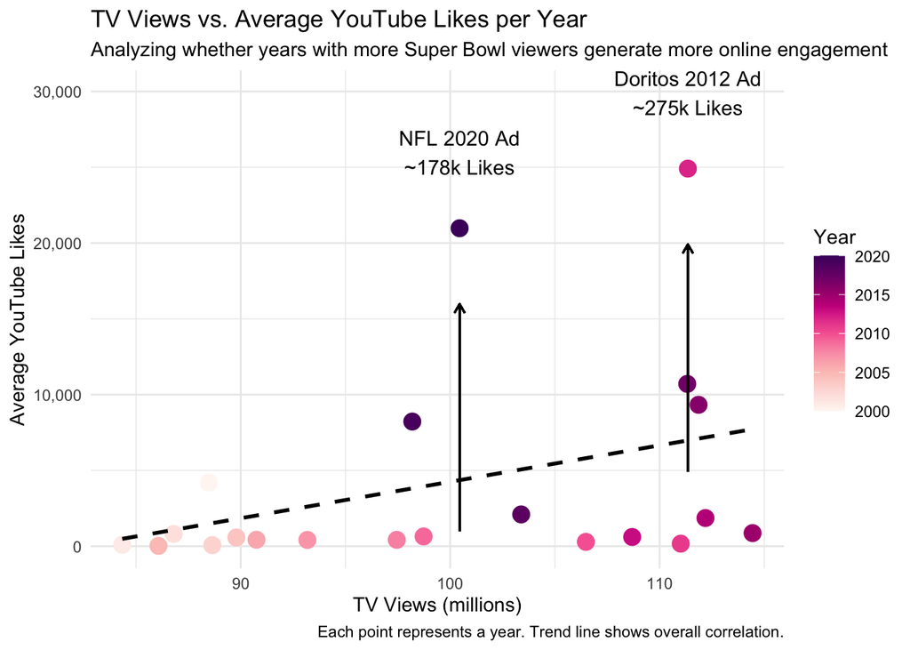

```r
# Scatter plot with color and annotations
ggplot(yearly_engagement, aes(x = tv_views_million, y = avg_likes, color = year)) +
  geom_point(size = 4) +  # Bigger points
  geom_smooth(method = "lm", se = FALSE, color = "black", linetype = "dashed") +  # Trend line
  scale_x_continuous(labels = scales::comma) +
  scale_y_continuous(labels = scales::comma) +
  scale_color_gradientn(colors = brewer.pal(n = 9, name = "RdPu")) +  # Apply color scheme
  labs(
    title = "TV Views vs. Average YouTube Likes per Year",
    subtitle = "Analyzing whether years with more Super Bowl viewers generate more online engagement",
    x = "TV Views (millions)",
    y = "Average YouTube Likes",
    color = "Year",
    caption = "Each point represents a year. Trend line shows overall correlation."
  ) +
  theme_minimal() +

  # Annotation for Max Outlier (Doritos 2012 Ad)
  annotate("text", x = max_outlier$tv_views_million, y = max_outlier$avg_likes + 5000,
           label = "Doritos 2012 Ad\n~275k Likes", color = "black", size = 4, hjust = 0.5) +
  geom_segment(aes(x = max_outlier$tv_views_million, y = max_outlier$avg_likes - 20000,
                   xend = max_outlier$tv_views_million, yend = max_outlier$avg_likes - 5000),
               arrow = arrow(length = unit(0.2, "cm")), color = "black") +

  # Annotation for Second Outlier
  annotate("text", x = second_outlier$tv_views_million, y = second_outlier$avg_likes + 5000,
           label = paste0("NFL 2020 Ad\n~178k Likes"),
           color = "black", size = 4, hjust = 0.5) +
  geom_segment(aes(x = second_outlier$tv_views_million, y = second_outlier$avg_likes - 20000,
                   xend = second_outlier$tv_views_million, yend = second_outlier$avg_likes - 5000),
               arrow = arrow(length = unit(0.2, "cm")), color = "black")
```

**Findings: The Impact of TV Exposure on YouTube Likes**

The revised scatter plot provided more context by specifically highlighting two major outliers: • 2012 Doritos Ad (275K likes) • 2020 NFL LIV Commercial (175K likes)

Additionally, the visualization used a ColorBrewer palette to differentiate the years, making it easier to spot trends over time. This helped reveal a positive correlation between TV views and online engagement, suggesting that in years with higher TV viewership, ads also received more YouTube likes. However, this trend was heavily influenced by the two outliers, indicating that virality, rather than TV exposure alone, may be a key driver of engagement.

**Possible Explanations** 1. Changing Viewing Habits & Online Presence • Over the years, people have become more active online, leading to higher engagement rates regardless of TV viewership. • The increase in social media usage and YouTube popularity likely contributes to the rising trend in likes over time. 2. How People Watch the Super Bowl Has Changed • In the early 2000s, many people watched the game in sports bars or large group settings, where engagement with ads may have been lower. • Today, many viewers watch individually on personal devices and engage more actively by liking and sharing ads online. • Some may even skip TV ads altogether and watch the best commercials later on YouTube. 3. Platform Shifts: The TikTok & Instagram Factor • Engagement patterns may be changing, with younger audiences shifting from YouTube to platforms like TikTok and Instagram. • Companies may now focus more on short-form ad placements, which could explain why YouTube likes alone may not capture the full picture of ad success.

While TV exposure may still play a role in ad success, online engagement is shaped by many other factors, from virality and content strategy to shifts in audience behavior.

**Future Considerations:**

- Expanding engagement analysis beyond YouTube (e.g., Twitter, TikTok, and sales data).
- Investigating whether certain ad types lead to increased product sales.
- Analyzing sentiment analysis from YouTube comments to understand audience reactions.

Prepared by Ghadena Hgaig

January 2025